# modeling

## look for interaction term

```r
# Univariable regression for screening main effects for reading_score
significant_vars_reading <- c()  # Save significant variables

for (var in names(model_data)[-c(28:30)]) {  # Exclude the score columns
  formula <- as.formula(paste("reading_score ~", var))  # Update for reading_score
  model <- lm(formula, data = model_data)
  if (summary(model)$coefficients[2, 4] < 0.05) {  # Check if p-value < 0.05
    significant_vars_reading <- c(significant_vars_reading, var)
  }
}

# Print significant variables
print(significant_vars_reading)
```

```
##  [1] "gender"                        "ethnic_groupgroup_e"
##  [3] "parent_educassociates_degree"  "parent_educbachelors_degree"
##  [5] "parent_educhigh_school"        "parent_educmasters_degree"
##  [7] "parent_educsome_high_school"   "lunch_type"
##  [9] "parent_marital_statusdivorced" "parent_marital_statusmarried"
## [11] "wkly_study_hours_5"
```

```r
# Generate interaction terms for significant variables
interaction_candidates_reading <- combn(significant_vars_reading, 2,
                                        function(x) paste(x, collapse = ":"))
# Print interaction terms
print(interaction_candidates_reading)
```

```
##  [1] "gender:ethnic_groupgroup_e"
##  [2] "gender:parent_educassociates_degree"
##  [3] "gender:parent_educbachelors_degree"
##  [4] "gender:parent_educhigh_school"
##  [5] "gender:parent_educmasters_degree"
##  [6] "gender:parent_educsome_high_school"
##  [7] "gender:lunch_type"
##  [8] "gender:parent_marital_statusdivorced"
##  [9] "gender:parent_marital_statusmarried"
## [10] "gender:wkly_study_hours_5"
## [11] "ethnic_groupgroup_e:parent_educassociates_degree"
## [12] "ethnic_groupgroup_e:parent_educbachelors_degree"
## [13] "ethnic_groupgroup_e:parent_educhigh_school"
## [14] "ethnic_groupgroup_e:parent_educmasters_degree"
## [15] "ethnic_groupgroup_e:parent_educsome_high_school"
```

[output cut: 40 more lines]

```r
# Selected interaction terms for reading_score
interaction_terms_reading <- c(
  "gender:ethnic_groupgroup_e",  # Gender and specific ethnic group
  "gender:parent_educbachelors_degree",  # Gender and parent's education
  "ethnic_groupgroup_e:parent_educmasters_degree",  # Ethnic group and parent's education
  "wkly_study_hours_5:lunch_type",  # Weekly study hours and lunch type
  "gender:wkly_study_hours_5",  # Gender and weekly study hours
  "parent_marital_statusmarried:lunch_type",  # Marital status and lunch type
  "gender:parent_marital_statusdivorced"  # Gender and marital status
)

# Check if all components of interaction terms exist in model_data
valid_interaction_terms <- interaction_terms_reading[
  sapply(interaction_terms_reading, function(term) {
    all(unlist(strsplit(term, ":")) %in% names(model_data))
  })
]

# Print valid interaction terms
print(valid_interaction_terms)
```

```
## [1] "gender:ethnic_groupgroup_e"
## [2] "gender:parent_educbachelors_degree"
## [3] "ethnic_groupgroup_e:parent_educmasters_degree"
## [4] "wkly_study_hours_5:lunch_type"
## [5] "gender:wkly_study_hours_5"
## [6] "parent_marital_statusmarried:lunch_type"
## [7] "gender:parent_marital_statusdivorced"
```

```r
# Construct the formula dynamically with valid interaction terms
interaction_formula_reading <- paste("reading_score ~ . +", paste(valid_interaction_terms, collapse = " + "))

# Fit the interaction model
interaction_model_reading <- lm(as.formula(interaction_formula_reading),
                                data = model_data[, c(names(X_reading), "reading_score")])
summary(interaction_model_reading)
```

```
##
## Call:
## lm(formula = as.formula(interaction_formula_reading), data = model_data[,
##     c(names(X_reading), "reading_score")])
##
## Residuals:
##     Min      1Q  Median      3Q     Max
## -46.241  -8.939   0.637   9.567  32.403
##
## Coefficients:
##                                               Estimate Std. Error t value
## (Intercept)                                   59.46864    6.50828   9.137
## gender                                        -8.33686    1.23003  -6.778
## ethnic_groupgroup_a                            1.22347    2.44281   0.501
## ethnic_groupgroup_b                            1.21139    2.11567   0.573
## ethnic_groupgroup_c                            1.49469    2.02878   0.737
## ethnic_groupgroup_d                            3.83961    2.05202   1.871
## ethnic_groupgroup_e                            4.50515    2.66993   1.687
## parent_educassociates_degree                   5.20907    2.17702   2.393
## parent_educbachelors_degree                    8.16606    2.72403   2.998
## parent_educhigh_school                        -0.97397    2.19358  -0.444
## parent_educmasters_degree                      8.96326    2.81382   3.185
## parent_educsome_college                        3.56949    2.16968   1.645
## parent_educsome_high_school                    0.65793    2.21451   0.297
## lunch_type                                     7.92450    1.52982   5.180
## test_prep                                      1.56474    1.95462   0.801
## parent_marital_statusdivorced                 -2.23999    2.65291  -0.844
## parent_marital_statusmarried                   2.65366    2.46700   1.076
## parent_marital_statussingle                    0.07535    2.25336   0.033
## parent_marital_statuswidowed                   3.88210    3.45625   1.123
## practice_sportnever                           -1.14227    3.76961  -0.303
## practice_sportregularly                       -1.13056    3.61120  -0.313
## practice_sportsometimes                       -0.33648    3.59655  -0.094
## is_first_child                                -0.54285    2.63250  -0.206
## nr_siblings                                   -0.08923    0.30746  -0.290
## transport_means                                0.34033    1.50697   0.226
## wkly_study_hours_5                            -1.08100    2.94536  -0.367
## wkly_study_hours_10                            1.58028    2.53592   0.623
## wkly_study_hours10_may                         1.73336    2.34456   0.739
## gender:ethnic_groupgroup_e                     2.39988    2.76132   0.869
```

[output cut: 33 more lines]

```
## wkly_study_hours_10                             0.5333
## wkly_study_hours10_may                          0.4599
## gender:ethnic_groupgroup_e                      0.3850
## gender:parent_educbachelors_degree              0.2555
## ethnic_groupgroup_e:parent_educmasters_degree   0.2593
## lunch_type:wkly_study_hours_5                   0.1910
## gender:wkly_study_hours_5                       0.0856 .
## lunch_type:parent_marital_statusmarried         0.8881
## gender:parent_marital_statusdivorced            0.2278
## ---
## Signif. codes:  0 '***' 0.001 '**' 0.01 '*' 0.05 '.' 0.1 ' ' 1
##
## Residual standard error: 13.49 on 867 degrees of freedom
## Multiple R-squared:  0.2025, Adjusted R-squared:  0.1713
## F-statistic: 6.476 on 34 and 867 DF,  p-value: < 2.2e-16
```

```r
# Compute Adjusted R^2 for both models
adj_r2_backward_reading <- summary(backward_model_reading)$adj.r.squared
adj_r2_interaction_reading <- summary(interaction_model_reading)$adj.r.squared

cat("Adjusted R^2 of Backward Model:", adj_r2_backward_reading, "\n")
```

```
## Adjusted R^2 of Backward Model: 0.17857
```

```r
cat("Adjusted R^2 of Interaction Model:", adj_r2_interaction_reading, "\n")
```

```
## Adjusted R^2 of Interaction Model: 0.1712593
```

```r
# Compute AIC and BIC for both models
aic_backward_reading <- AIC(backward_model_reading)
bic_backward_reading <- BIC(backward_model_reading)

aic_interaction_reading <- AIC(interaction_model_reading)
bic_interaction_reading <- BIC(interaction_model_reading)

cat("AIC of Backward Model:", aic_backward_reading, "\n")
```

```
## AIC of Backward Model: 7260.187
```

```r
cat("BIC of Backward Model:", bic_backward_reading, "\n")
```

```
## BIC of Backward Model: 7322.647
```

```r
cat("AIC of Interaction Model:", aic_interaction_reading, "\n")
```

```
## AIC of Interaction Model: 7290.562
```

```r
cat("BIC of Interaction Model:", bic_interaction_reading, "\n")
```

```
## BIC of Interaction Model: 7463.528
```

```r
anova_result <- anova(backward_model_reading, interaction_model_reading)
print(anova_result)
```

```
## Analysis of Variance Table
##
## Model 1: reading_score ~ gender + ethnic_groupgroup_d + ethnic_groupgroup_e +
##     parent_educassociates_degree + parent_educbachelors_degree +
##     parent_educmasters_degree + parent_educsome_college + lunch_type +
##     parent_marital_statusmarried + wkly_study_hours_10 + wkly_study_hours10_may
## Model 2: reading_score ~ gender + ethnic_groupgroup_a + ethnic_groupgroup_b +
##     ethnic_groupgroup_c + ethnic_groupgroup_d + ethnic_groupgroup_e +
##     parent_educassociates_degree + parent_educbachelors_degree +
##     parent_educhigh_school + parent_educmasters_degree + parent_educsome_college +
##     parent_educsome_high_school + lunch_type + test_prep + parent_marital_statusdivorced +
##     parent_marital_statusmarried + parent_marital_statussingle +
##     parent_marital_statuswidowed + practice_sportnever + practice_sportregularly +
##     practice_sportsometimes + is_first_child + nr_siblings +
##     transport_means + wkly_study_hours_5 + wkly_study_hours_10 +
##     wkly_study_hours10_may + gender:ethnic_groupgroup_e + gender:parent_educbachelors_degree +
##     ethnic_groupgroup_e:parent_educmasters_degree + wkly_study_hours_5:lunch_type +
##     gender:wkly_study_hours_5 + parent_marital_statusmarried:lunch_type +
##     gender:parent_marital_statusdivorced
##   Res.Df    RSS Df Sum of Sq      F Pr(>F)
## 1    890 160637
## 2    867 157878 23    2758.6 0.6586 0.8873
```

Based on the anova result, including interaction term does not significantly improve our model, therefore, we will not include interaction term into our model.

## model diagnostic

### normality

```r
shapiro.test(residuals(backward_model_reading))
```

```
##
##  Shapiro-Wilk normality test
##
## data:  residuals(backward_model_reading)
## W = 0.99243, p-value = 0.0001452
```

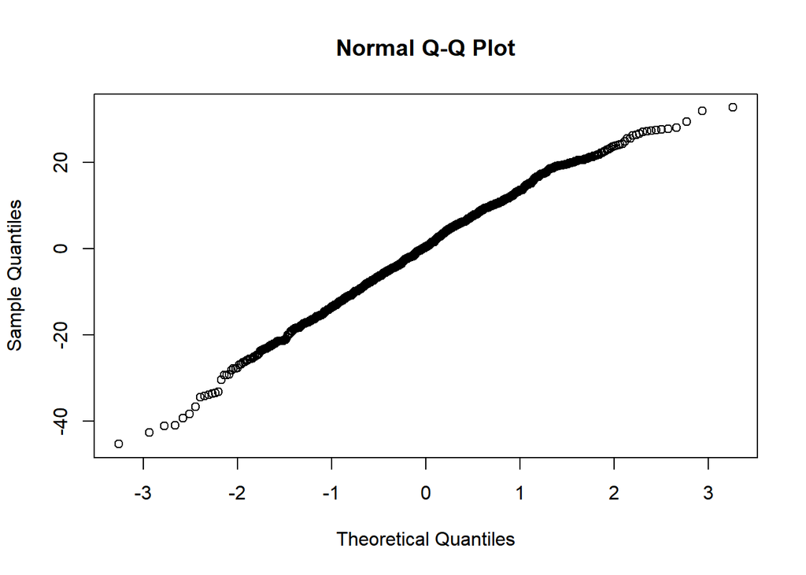

```r
qqnorm(residuals(backward_model_reading))
```

### Independence of Residuals

```r
dwtest(backward_model_reading)
```

```
##
##  Durbin-Watson test
##
## data:  backward_model_reading
## DW = 1.9941, p-value = 0.4655
## alternative hypothesis: true autocorrelation is greater than 0
```

### Multicollinearity Check

```r
vif(backward_model_reading)
```

```
##                       gender          ethnic_groupgroup_d
##                     1.010531                     1.064046
##          ethnic_groupgroup_e parent_educassociates_degree
##                     1.064173                     1.201094
##  parent_educbachelors_degree    parent_educmasters_degree
##                     1.137574                     1.083129
##      parent_educsome_college                   lunch_type
##                     1.203298                     1.008267
## parent_marital_statusmarried          wkly_study_hours_10
##                     1.012344                     1.292459
##       wkly_study_hours10_may
##                     1.282038
```

### constant variance

```r
bptest(backward_model_reading)
```

```
##
##  studentized Breusch-Pagan test
##
## data:  backward_model_reading
## BP = 9.8681, df = 11, p-value = 0.5423
```

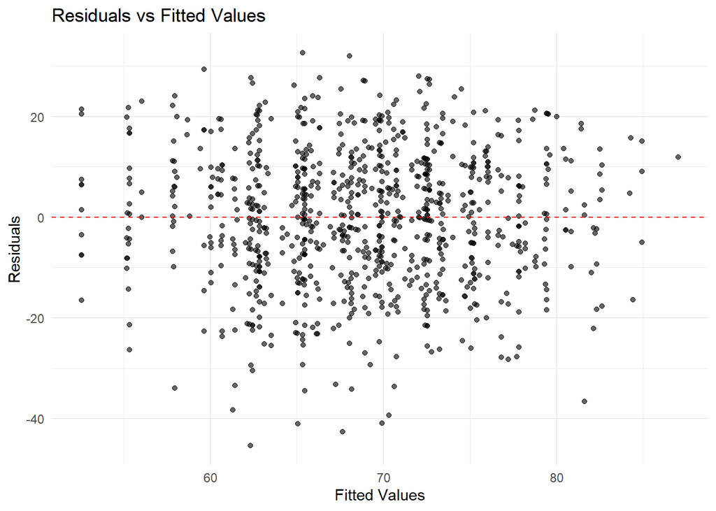

```r
residuals <- residuals(backward_model_reading)
fitted_values <- fitted(backward_model_reading)

# Create a data frame for ggplot
residuals_df <- data.frame(Fitted = fitted_values, Residuals = residuals)

# Plot Residuals vs Fitted Values
ggplot(residuals_df, aes(x = Fitted, y = Residuals)) +
  geom_point(alpha = 0.6) +  # Add points
  geom_hline(yintercept = 0, color = "red", linetype = "dashed") +  # Reference line at 0
  labs(
    title = "Residuals vs Fitted Values",
    x = "Fitted Values",
    y = "Residuals"
  ) +
  theme_minimal()
```

##box-cox

```r
boxcox_result_reading <- boxcox(backward_model_reading, lambda = seq(-2, 2, 0.1))
```

[figure not shown]

```r
# Find the lambda that maximizes log-likelihood
lambda_best_reading <- boxcox_result$x[which.max(boxcox_result$y)]
cat("Optimal Lambda:", lambda_best_reading, "\n")
```

```
## Optimal Lambda: 1.313131
```

```r
if (lambda_best_reading == 0) {
  model_data$reading_score_trans <- log(model_data$reading_score)
} else {
  model_data$reading_score_trans <- (model_data$reading_score^lambda_best_reading - 1) / lambda_best_reading
}

# Fit a new model with the transformed dependent variable
boxcox_model_reading <- lm(reading_score_trans ~ ., data = model_data[, c(colnames(X_reading), "reading_score_trans")])
summary(boxcox_model_reading)
```

```
##
## Call:
## lm(formula = reading_score_trans ~ ., data = model_data[, c(colnames(X_reading),
##     "reading_score_trans")])
##
## Residuals:
##      Min       1Q   Median       3Q      Max
## -147.711  -34.931    0.503   35.277  126.302
##
## Coefficients:
##                               Estimate Std. Error t value Pr(>|t|)
## (Intercept)                   160.9182    23.8803   6.739 2.90e-11 ***
## gender                        -26.5176     3.3792  -7.847 1.24e-14 ***
## ethnic_groupgroup_a             5.5928     9.0496   0.618 0.536722
## ethnic_groupgroup_b             6.3128     7.8443   0.805 0.421172
## ethnic_groupgroup_c             7.2351     7.5046   0.964 0.335266
## ethnic_groupgroup_d            15.6834     7.5986   2.064 0.039315 *
## ethnic_groupgroup_e            24.5926     8.2564   2.979 0.002976 **
## parent_educassociates_degree   20.6316     8.0624   2.559 0.010665 *
## parent_educbachelors_degree    26.0247     8.8336   2.946 0.003304 **
## parent_educhigh_school         -2.9122     8.1251  -0.358 0.720113
## parent_educmasters_degree      36.1997    10.0066   3.618 0.000314 ***
## parent_educsome_college        13.7734     8.0364   1.714 0.086909 .
## parent_educsome_high_school     4.2918     8.1986   0.523 0.600771
## lunch_type                     27.6220     3.5240   7.838 1.33e-14 ***
## test_prep                       5.2244     7.2150   0.724 0.469199
## parent_marital_statusdivorced  -2.3281     8.6847  -0.268 0.788710
## parent_marital_statusmarried    9.6659     7.8575   1.230 0.218973
## parent_marital_statussingle    -0.1047     8.3469  -0.013 0.989991
## parent_marital_statuswidowed   15.3913    12.8214   1.200 0.230293
## practice_sportnever            -4.4455    13.9591  -0.318 0.750206
## practice_sportregularly        -4.2818    13.3824  -0.320 0.749076
## practice_sportsometimes        -1.2867    13.3161  -0.097 0.923047
## is_first_child                 -2.7518     9.7112  -0.283 0.776964
## nr_siblings                    -0.2783     1.1409  -0.244 0.807311
## transport_means                 1.6663     5.5771   0.299 0.765184
## wkly_study_hours_5             -3.8355     8.9416  -0.429 0.668062
## wkly_study_hours_10             6.4255     9.3775   0.685 0.493395
## wkly_study_hours10_may          6.7460     8.6697   0.778 0.436716
## ---
## Signif. codes:  0 '***' 0.001 '**' 0.01 '*' 0.05 '.' 0.1 ' ' 1
##
## Residual standard error: 50.1 on 874 degrees of freedom
## Multiple R-squared:  0.197,  Adjusted R-squared:  0.1722
## F-statistic: 7.943 on 27 and 874 DF,  p-value: < 2.2e-16
```

## compare with original model

```r
# Compare Adjusted R^2
adj_r2_original_reading <- summary(backward_model_reading)$adj.r.squared
adj_r2_boxcox_reading <- summary(boxcox_model_reading)$adj.r.squared

# Compare AIC and BIC
aic_original_reading <- AIC(backward_model_reading)
bic_original_reading <- BIC(backward_model_reading)

aic_boxcox_reading <- AIC(boxcox_model_reading)
bic_boxcox_reading <- BIC(boxcox_model_reading)

# Print comparison
comparison_reading <- data.frame(
  Metric = c("Adjusted R^2", "AIC", "BIC"),
  Original_Model = c(adj_r2_original_reading, aic_original_reading, bic_original_reading),
  BoxCox_Model = c(adj_r2_boxcox_reading, aic_boxcox_reading, bic_boxcox_reading)
)

print(comparison_reading)
```

```
##         Metric Original_Model BoxCox_Model
## 1 Adjusted R^2        0.17857    0.1722279
## 2          AIC     7260.18663 9650.2332136
## 3          BIC     7322.64662 9789.5670347
```

# Writing Score

```r
# Select predictors, excluding the score columns
X_writing <- model_data %>%
  select(-math_score, -reading_score, -writing_score)

# Define the response variable
y_writing <- model_data$writing_score
```

## Backward elimination

```r
# The initial full-variable model for writing_score
full_model_writing <- lm(writing_score ~ ., data = model_data[, c(colnames(X_writing), "writing_score")])

backward_model_writing <- stepAIC(full_model_writing, direction = "backward")
```

```
## Start:  AIC=2671.27
## writing_score ~ gender + ethnic_groupgroup_a + ethnic_groupgroup_b +
##     ethnic_groupgroup_c + ethnic_groupgroup_d + ethnic_groupgroup_e +
##     parent_educassociates_degree + parent_educbachelors_degree +
##     parent_educhigh_school + parent_educmasters_degree + parent_educsome_college +
##     parent_educsome_high_school + lunch_type + test_prep + parent_marital_statusdivorced +
##     parent_marital_statusmarried + parent_marital_statussingle +
##     parent_marital_statuswidowed + practice_sportnever + practice_sportregularly +
##     practice_sportsometimes + is_first_child + nr_siblings +
##     transport_means + wkly_study_hours_5 + wkly_study_hours_10 +
##     wkly_study_hours10_may + reading_score_trans
##
##                                 Df Sum of Sq    RSS    AIC
## - parent_educbachelors_degree    1         0  16348 2669.3
## - wkly_study_hours_10            1         0  16348 2669.3
## - is_first_child                 1         1  16348 2669.3
## - parent_marital_statuswidowed   1         1  16348 2669.3
## - test_prep                      1         2  16349 2669.4
## - wkly_study_hours10_may         1         3  16350 2669.4
## - parent_educmasters_degree      1         3  16350 2669.4
## - practice_sportnever            1         3  16350 2669.4
## - practice_sportsometimes        1         5  16352 2669.5
## - wkly_study_hours_5             1         5  16352 2669.5
## - parent_marital_statussingle    1        11  16358 2669.9
## - transport_means                1        13  16361 2670.0
## - parent_marital_statusdivorced  1        20  16367 2670.4
## - ethnic_groupgroup_c            1        29  16376 2670.9
## - parent_educsome_college        1        31  16378 2671.0
## - parent_marital_statusmarried   1        31  16378 2671.0
## - practice_sportregularly        1        36  16383 2671.2
## <none>                                        16347 2671.3
## - parent_educassociates_degree   1        46  16393 2671.8
## - nr_siblings                    1        46  16393 2671.8
## - ethnic_groupgroup_d            1        49  16396 2672.0
## - ethnic_groupgroup_e            1        51  16398 2672.1
## - ethnic_groupgroup_b            1        59  16406 2672.5
## - ethnic_groupgroup_a            1        60  16407 2672.6
## - parent_educsome_high_school    1       217  16564 2681.2
## - parent_educhigh_school         1       257  16604 2683.3
## - lunch_type                     1       319  16666 2686.7
```

[output cut: 509 more lines]

```
##     nr_siblings + reading_score_trans
##
##                                Df Sum of Sq    RSS    AIC
## <none>                                       16510 2646.2
## - nr_siblings                   1        51  16561 2647.0
## - parent_educsome_college       1        78  16588 2648.5
## - practice_sportsometimes       1       104  16615 2649.9
## - parent_educassociates_degree  1       107  16617 2650.1
## - lunch_type                    1       324  16834 2661.8
## - practice_sportregularly       1       366  16877 2664.0
## - parent_educsome_high_school   1       528  17038 2672.6
## - parent_educhigh_school        1       616  17127 2677.3
## - ethnic_groupgroup_d           1       716  17226 2682.5
## - gender                        1      1077  17588 2701.2
## - reading_score_trans           1    150015 166525 4728.9
```

```r
# Summary of the backward elimination model
summary(backward_model_writing)
```

```
##
## Call:
## lm(formula = writing_score ~ gender + ethnic_groupgroup_d + parent_educassociates_degree +
##     parent_educhigh_school + parent_educsome_college + parent_educsome_high_school +
##     lunch_type + practice_sportregularly + practice_sportsometimes +
##     nr_siblings + reading_score_trans, data = model_data[, c(colnames(X_writing),
##     "writing_score")])
##
## Residuals:
##      Min       1Q   Median       3Q      Max
## -14.7003  -3.1372  -0.1281   2.9278  13.4982
##
## Coefficients:
##                               Estimate Std. Error t value Pr(>|t|)
## (Intercept)                  16.845106   0.813312  20.712  < 2e-16 ***
## gender                       -2.269380   0.297789  -7.621 6.45e-14 ***
## ethnic_groupgroup_d           2.061229   0.331757   6.213 7.97e-10 ***
## parent_educassociates_degree -1.059593   0.441142  -2.402   0.0165 *
## parent_educhigh_school       -2.649147   0.459541  -5.765 1.13e-08 ***
## parent_educsome_college      -0.895980   0.437342  -2.049   0.0408 *
## parent_educsome_high_school  -2.481223   0.465213  -5.334 1.22e-07 ***
## lunch_type                    1.302389   0.311639   4.179 3.21e-05 ***
## practice_sportregularly       2.045989   0.460357   4.444 9.93e-06 ***
## practice_sportsometimes       1.048007   0.442037   2.371   0.0180 *
## nr_siblings                   0.160843   0.097056   1.657   0.0978 .
## reading_score_trans           0.254537   0.002831  89.926  < 2e-16 ***
## ---
## Signif. codes:  0 '***' 0.001 '**' 0.01 '*' 0.05 '.' 0.1 ' ' 1
##
## Residual standard error: 4.307 on 890 degrees of freedom
## Multiple R-squared:  0.9222, Adjusted R-squared:  0.9213
## F-statistic: 959.7 on 11 and 890 DF,  p-value: < 2.2e-16
```

## criteria-based

```r
# Perform stepwise selection based on AIC
aic_model_writing <- stepAIC(full_model_writing, direction = "both", k = 2)
```

```
## Start:  AIC=2671.27
## writing_score ~ gender + ethnic_groupgroup_a + ethnic_groupgroup_b +
##     ethnic_groupgroup_c + ethnic_groupgroup_d + ethnic_groupgroup_e +
##     parent_educassociates_degree + parent_educbachelors_degree +
##     parent_educhigh_school + parent_educmasters_degree + parent_educsome_college +
##     parent_educsome_high_school + lunch_type + test_prep + parent_marital_statusdivorced +
##     parent_marital_statusmarried + parent_marital_statussingle +
##     parent_marital_statuswidowed + practice_sportnever + practice_sportregularly +
##     practice_sportsometimes + is_first_child + nr_siblings +
##     transport_means + wkly_study_hours_5 + wkly_study_hours_10 +
##     wkly_study_hours10_may + reading_score_trans
##
##                                 Df Sum of Sq    RSS    AIC
## - parent_educbachelors_degree    1         0  16348 2669.3
## - wkly_study_hours_10            1         0  16348 2669.3
## - is_first_child                 1         1  16348 2669.3
## - parent_marital_statuswidowed   1         1  16348 2669.3
## - test_prep                      1         2  16349 2669.4
## - wkly_study_hours10_may         1         3  16350 2669.4
## - parent_educmasters_degree      1         3  16350 2669.4
## - practice_sportnever            1         3  16350 2669.4
## - practice_sportsometimes        1         5  16352 2669.5
## - wkly_study_hours_5             1         5  16352 2669.5
## - parent_marital_statussingle    1        11  16358 2669.9
## - transport_means                1        13  16361 2670.0
## - parent_marital_statusdivorced  1        20  16367 2670.4
## - ethnic_groupgroup_c            1        29  16376 2670.9
## - parent_educsome_college        1        31  16378 2671.0
## - parent_marital_statusmarried   1        31  16378 2671.0
## - practice_sportregularly        1        36  16383 2671.2
## <none>                                        16347 2671.3
## - parent_educassociates_degree   1        46  16393 2671.8
## - nr_siblings                    1        46  16393 2671.8
## - ethnic_groupgroup_d            1        49  16396 2672.0
## - ethnic_groupgroup_e            1        51  16398 2672.1
## - ethnic_groupgroup_b            1        59  16406 2672.5
## - ethnic_groupgroup_a            1        60  16407 2672.6
## - parent_educsome_high_school    1       217  16564 2681.2
## - parent_educhigh_school         1       257  16604 2683.3
## - lunch_type                     1       319  16666 2686.7
```

[output cut: 662 more lines]

```
## + test_prep                      1         2  16508 2648.1
## + parent_educbachelors_degree    1         2  16509 2648.1
## + is_first_child                 1         2  16509 2648.1
## + wkly_study_hours10_may         1         0  16510 2648.2
## + parent_marital_statusdivorced  1         0  16510 2648.2
## - parent_educsome_college        1        78  16588 2648.5
## - practice_sportsometimes        1       104  16615 2649.9
## - parent_educassociates_degree   1       107  16617 2650.1
## - lunch_type                     1       324  16834 2661.8
## - practice_sportregularly        1       366  16877 2664.0
## - parent_educsome_high_school    1       528  17038 2672.6
## - parent_educhigh_school         1       616  17127 2677.3
## - ethnic_groupgroup_d            1       716  17226 2682.5
## - gender                         1      1077  17588 2701.2
## - reading_score_trans            1    150015 166525 4728.9
```

```r
# Summary of the AIC-based stepwise selection model
summary(aic_model_writing)
```

```
##
## Call:
## lm(formula = writing_score ~ gender + ethnic_groupgroup_d + parent_educassociates_degree +
##     parent_educhigh_school + parent_educsome_college + parent_educsome_high_school +
##     lunch_type + practice_sportregularly + practice_sportsometimes +
##     nr_siblings + reading_score_trans, data = model_data[, c(colnames(X_writing),
##     "writing_score")])
##
## Residuals:
##      Min       1Q   Median       3Q      Max
## -14.7003  -3.1372  -0.1281   2.9278  13.4982
##
## Coefficients:
##                               Estimate Std. Error t value Pr(>|t|)
## (Intercept)                  16.845106   0.813312  20.712  < 2e-16 ***
## gender                       -2.269380   0.297789  -7.621 6.45e-14 ***
## ethnic_groupgroup_d           2.061229   0.331757   6.213 7.97e-10 ***
## parent_educassociates_degree -1.059593   0.441142  -2.402   0.0165 *
## parent_educhigh_school       -2.649147   0.459541  -5.765 1.13e-08 ***
## parent_educsome_college      -0.895980   0.437342  -2.049   0.0408 *
## parent_educsome_high_school  -2.481223   0.465213  -5.334 1.22e-07 ***
## lunch_type                    1.302389   0.311639   4.179 3.21e-05 ***
## practice_sportregularly       2.045989   0.460357   4.444 9.93e-06 ***
## practice_sportsometimes       1.048007   0.442037   2.371   0.0180 *
## nr_siblings                   0.160843   0.097056   1.657   0.0978 .
## reading_score_trans           0.254537   0.002831  89.926  < 2e-16 ***
## ---
## Signif. codes:  0 '***' 0.001 '**' 0.01 '*' 0.05 '.' 0.1 ' ' 1
##
## Residual standard error: 4.307 on 890 degrees of freedom
## Multiple R-squared:  0.9222, Adjusted R-squared:  0.9213
## F-statistic: 959.7 on 11 and 890 DF,  p-value: < 2.2e-16
```

```r
# Perform stepwise selection based on BIC
bic_model_writing <- stepAIC(full_model_writing, direction = "both", k = log(nrow(model_data)))
```

```
## Start:  AIC=2810.6
## writing_score ~ gender + ethnic_groupgroup_a + ethnic_groupgroup_b +
##     ethnic_groupgroup_c + ethnic_groupgroup_d + ethnic_groupgroup_e +
##     parent_educassociates_degree + parent_educbachelors_degree +
##     parent_educhigh_school + parent_educmasters_degree + parent_educsome_college +
##     parent_educsome_high_school + lunch_type + test_prep + parent_marital_statusdivorced +
##     parent_marital_statusmarried + parent_marital_statussingle +
##     parent_marital_statuswidowed + practice_sportnever + practice_sportregularly +
##     practice_sportsometimes + is_first_child + nr_siblings +
##     transport_means + wkly_study_hours_5 + wkly_study_hours_10 +
##     wkly_study_hours10_may + reading_score_trans
##
##                                 Df Sum of Sq    RSS    AIC
## - parent_educbachelors_degree    1         0  16348 2803.8
## - wkly_study_hours_10            1         0  16348 2803.8
## - is_first_child                 1         1  16348 2803.8
## - parent_marital_statuswidowed   1         1  16348 2803.8
## - test_prep                      1         2  16349 2803.9
## - wkly_study_hours10_may         1         3  16350 2803.9
## - parent_educmasters_degree      1         3  16350 2803.9
## - practice_sportnever            1         3  16350 2804.0
## - practice_sportsometimes        1         5  16352 2804.0
## - wkly_study_hours_5             1         5  16352 2804.1
## - parent_marital_statussingle    1        11  16358 2804.4
## - transport_means                1        13  16361 2804.5
## - parent_marital_statusdivorced  1        20  16367 2804.9
## - ethnic_groupgroup_c            1        29  16376 2805.4
## - parent_educsome_college        1        31  16378 2805.5
## - parent_marital_statusmarried   1        31  16378 2805.5
## - practice_sportregularly        1        36  16383 2805.8
## - parent_educassociates_degree   1        46  16393 2806.3
## - nr_siblings                    1        46  16393 2806.3
## - ethnic_groupgroup_d            1        49  16396 2806.5
## - ethnic_groupgroup_e            1        51  16398 2806.6
## - ethnic_groupgroup_b            1        59  16406 2807.0
## - ethnic_groupgroup_a            1        60  16407 2807.1
## <none>                                        16347 2810.6
## - parent_educsome_high_school    1       217  16564 2815.7
## - parent_educhigh_school         1       257  16604 2817.9
## - lunch_type                     1       319  16666 2821.2
```

[output cut: 807 more lines]

```
## + parent_marital_statussingle    1         7  16782 2698.2
## + wkly_study_hours_5             1         4  16785 2698.3
## + wkly_study_hours_10            1         4  16786 2698.4
## + parent_marital_statuswidowed   1         2  16787 2698.5
## + test_prep                      1         1  16788 2698.5
## + is_first_child                 1         1  16788 2698.5
## + parent_marital_statusdivorced  1         0  16789 2698.6
## + wkly_study_hours10_may         1         0  16789 2698.6
## - practice_sportregularly        1       269  17058 2699.3
## - lunch_type                     1       305  17095 2701.2
## - parent_educsome_high_school    1       423  17212 2707.4
## - parent_educhigh_school         1       471  17260 2709.9
## - ethnic_groupgroup_d            1       751  17540 2724.4
## - gender                         1      1124  17913 2743.4
## - reading_score_trans            1    150746 167536 4760.0
```

```r
# Summary of the BIC-based stepwise selection model
summary(bic_model_writing)
```

```
##
## Call:
## lm(formula = writing_score ~ gender + ethnic_groupgroup_d + parent_educhigh_school +
##     parent_educsome_high_school + lunch_type + practice_sportregularly +
##     reading_score_trans, data = model_data[, c(colnames(X_writing),
##     "writing_score")])
##
## Residuals:
##      Min       1Q   Median       3Q      Max
## -14.4699  -3.0020  -0.1852   2.8600  13.7432
##
## Coefficients:
##                              Estimate Std. Error t value Pr(>|t|)
## (Intercept)                 17.391565   0.654007  26.592  < 2e-16 ***
## gender                      -2.314319   0.299190  -7.735 2.78e-14 ***
## ethnic_groupgroup_d          2.104464   0.332881   6.322 4.07e-10 ***
## parent_educhigh_school      -1.929629   0.385409  -5.007 6.67e-07 ***
## parent_educsome_high_school -1.873222   0.394829  -4.744 2.43e-06 ***
## lunch_type                   1.262934   0.313225   4.032 6.00e-05 ***
## practice_sportregularly      1.136906   0.300315   3.786 0.000163 ***
## reading_score_trans          0.254758   0.002843  89.593  < 2e-16 ***
## ---
## Signif. codes:  0 '***' 0.001 '**' 0.01 '*' 0.05 '.' 0.1 ' ' 1
##
## Residual standard error: 4.334 on 894 degrees of freedom
## Multiple R-squared:  0.9209, Adjusted R-squared:  0.9203
## F-statistic:  1488 on 7 and 894 DF,  p-value: < 2.2e-16
```

## lasso

```r
# Transform data into matrix form for LASSO
X_writing_matrix <- model.matrix(~ . - 1, data = X_writing)  # Predictors
y_writing_vector <- as.numeric(model_data$writing_score)  # Response variable

lasso_model_writing <- cv.glmnet(X_writing_matrix, y_writing_vector, alpha = 1, nfolds = 5)

# Extract the optimal lambda value
lambda_min_writing <- lasso_model_writing$lambda.min
cat("Optimal lambda:", lambda_min_writing, "\n")
```

```
## Optimal lambda: 0.1271196
```

```r
# Extract coefficients for the model with optimal lambda
lasso_coef_writing <- coef(lasso_model_writing, s = lambda_min_writing)
print(lasso_coef_writing)
```

```
## 29 x 1 sparse Matrix of class "dgCMatrix"
##                                        s1
## (Intercept)                   17.49365487
## gender                        -2.04622882
## ethnic_groupgroup_a           -0.17521748
## ethnic_groupgroup_b           -0.11506222
## ethnic_groupgroup_c            .
## ethnic_groupgroup_d            1.72543021
## ethnic_groupgroup_e            .
## parent_educassociates_degree   .
## parent_educbachelors_degree    0.50263065
## parent_educhigh_school        -1.43161779
## parent_educmasters_degree      0.67749494
## parent_educsome_college        .
## parent_educsome_high_school   -1.25641421
## lunch_type                     1.01597165
## test_prep                      .
## parent_marital_statusdivorced  .
## parent_marital_statusmarried   0.08805847
## parent_marital_statussingle    .
## parent_marital_statuswidowed   .
## practice_sportnever           -0.78094270
## practice_sportregularly        0.74565213
## practice_sportsometimes        .
## is_first_child                 .
## nr_siblings                    0.07023221
## transport_means                0.03542844
## wkly_study_hours_5             .
## wkly_study_hours_10            .
## wkly_study_hours10_may         .
## reading_score_trans            0.25359262
```

## comparison

```r
# Compare AIC and BIC for backward elimination
aic_backward_writing <- AIC(backward_model_writing)
bic_backward_writing <- BIC(backward_model_writing)

# Backward elimination's R2
r2_backward_writing <- summary(backward_model_writing)$r.squared
adj_r2_backward_writing <- summary(backward_model_writing)$adj.r.squared

# Compare AIC and BIC for AIC-based stepwise selection
aic_aic_model_writing <- AIC(aic_model_writing)
bic_aic_model_writing <- BIC(aic_model_writing)

# Compare AIC and BIC for BIC-based stepwise selection
aic_bic_model_writing <- AIC(bic_model_writing)
bic_bic_model_writing <- BIC(bic_model_writing)

# R2 of AIC model
r2_aic_writing <- summary(aic_model_writing)$r.squared
adj_r2_aic_writing <- summary(aic_model_writing)$adj.r.squared

# R2 of BIC model
r2_bic_writing <- summary(bic_model_writing)$r.squared
adj_r2_bic_writing <- summary(bic_model_writing)$adj.r.squared
```

```r
# Predictions from the LASSO model
predictions_writing <- predict(lasso_model_writing, newx = X_writing_matrix, s = lambda_min_writing)

# Calculate RSS and TSS
rss_writing <- sum((y_writing_vector - predictions_writing)^2)
tss_writing <- sum((y_writing_vector - mean(y_writing_vector))^2)

# Calculate AIC and BIC for LASSO
n_writing <- length(y_writing_vector)
k_writing <- sum(lasso_coef_writing != 0)  # Number of non-zero coefficients
aic_lasso_writing <- n_writing * log(rss_writing / n_writing) + 2 * k_writing
bic_lasso_writing <- n_writing * log(rss_writing / n_writing) + log(n_writing) * k_writing

# Adjusted R2 for LASSO
r2_lasso_writing <- 1 - (rss_writing / tss_writing)
adj_r2_lasso_writing <- 1 - ((1 - r2_lasso_writing) * (n_writing - 1) / (n_writing - k_writing - 1))
```

```r
# Compile results for all models
results_writing <- data.frame(
  Method = c("Backward", "Criteria-Based AIC", "Criteria-Based BIC", "LASSO"),
  AIC = c(aic_backward_writing, aic_aic_model_writing, aic_bic_model_writing, aic_lasso_writing),
  BIC = c(bic_backward_writing, bic_aic_model_writing, bic_bic_model_writing, bic_lasso_writing),
  Adj_R2 = c(adj_r2_backward_writing, adj_r2_aic_writing, adj_r2_bic_writing, adj_r2_lasso_writing)
)

# Print the results
print(results_writing)
```

```
##               Method      AIC      BIC    Adj_R2
## 1           Backward 5207.989 5270.449 0.9212862
## 2 Criteria-Based AIC 5207.989 5270.449 0.9212862
## 3 Criteria-Based BIC 5215.105 5258.346 0.9203141
## 4              LASSO 2661.934 2738.808 0.9201620
```

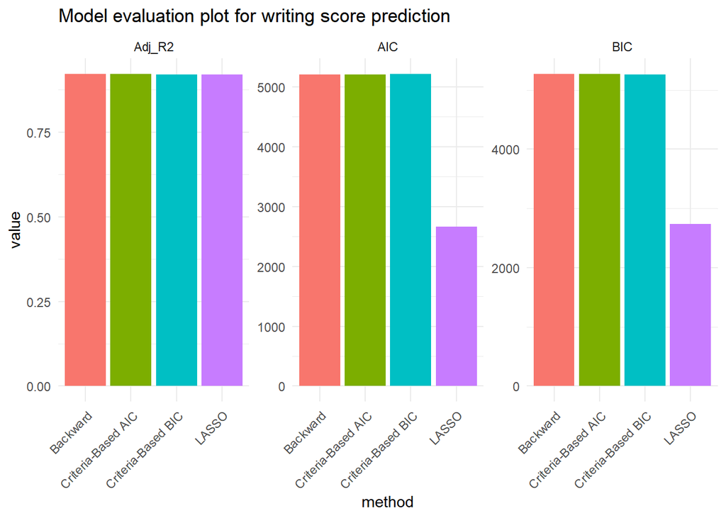

```r
results_long <- results_writing %>%
  pivot_longer(cols = c(AIC, BIC, Adj_R2),
               names_to = "Metric",
               values_to = "Value")

ggplot(results_long, aes(x = Method, y = Value, fill = Method)) +
  geom_bar(stat = "identity") +
  facet_wrap(~ Metric, scales = "free_y", ncol = 3) +  # 设置每行3个面板，即按列分布
  theme_minimal() +
  labs(title = "Model evaluation plot for writing score prediction",
       x = "method",
       y = "value") +
  theme(axis.text.x = element_text(angle = 45, hjust = 1),
        legend.position = "none")
```

## look for interaction terms

```r
# Univariable regression for screening main effects for writing_score
significant_vars_writing <- c()  # Save significant variables

for (var in names(model_data)[-c(28:30)]) {
  formula <- as.formula(paste("writing_score ~", var))  # Update to writing_score
  model <- lm(formula, data = model_data)
  if (summary(model)$coefficients[2, 4] < 0.05) {  # p-value < 0.05
    significant_vars_writing <- c(significant_vars_writing, var)
  }
}

print(significant_vars_writing)
```

```
##  [1] "gender"                       "ethnic_groupgroup_a"
##  [3] "ethnic_groupgroup_b"          "ethnic_groupgroup_d"
##  [5] "ethnic_groupgroup_e"          "parent_educassociates_degree"
##  [7] "parent_educbachelors_degree"  "parent_educhigh_school"
##  [9] "parent_educmasters_degree"    "parent_educsome_high_school"
## [11] "lunch_type"                   "parent_marital_statusmarried"
## [13] "wkly_study_hours_5"           "reading_score_trans"
```

```r
# Generate interaction terms for significant variables
interaction_candidates_writing <- combn(significant_vars_writing, 2,
                                        function(x) paste(x, collapse = ":"))

print(interaction_candidates_writing)
```

```
##  [1] "gender:ethnic_groupgroup_a"
##  [2] "gender:ethnic_groupgroup_b"
##  [3] "gender:ethnic_groupgroup_d"
##  [4] "gender:ethnic_groupgroup_e"
##  [5] "gender:parent_educassociates_degree"
##  [6] "gender:parent_educbachelors_degree"
##  [7] "gender:parent_educhigh_school"
##  [8] "gender:parent_educmasters_degree"
##  [9] "gender:parent_educsome_high_school"
## [10] "gender:lunch_type"
## [11] "gender:parent_marital_statusmarried"
## [12] "gender:wkly_study_hours_5"
## [13] "gender:reading_score_trans"
## [14] "ethnic_groupgroup_a:ethnic_groupgroup_b"
## [15] "ethnic_groupgroup_a:ethnic_groupgroup_d"
```

[output cut: 76 more lines]

```r
# Define interaction terms
interaction_terms <- c(
  "gender:ethnic_groupgroup_a",
  "gender:parent_educbachelors_degree",
  "ethnic_groupgroup_e:parent_educhigh_school",
  "parent_educbachelors_degree:parent_educhigh_school",
  "gender:parent_marital_statusmarried",
  "gender:lunch_type",
  "wkly_study_hours_5:reading_score_trans",
  "lunch_type:wkly_study_hours_5"
)
```

```r
# Prepare main effects model matrix with "writing" prefix/suffix
X_matrix_main_writing <- model.matrix(~ . - 1, data = X_writing)  # Use X_writing for predictors

# Define selected interaction terms with "writing" prefix/suffix
selected_interactions_writing <- c(
  "gender:ethnic_groupgroup_a",
  "gender:parent_educbachelors_degree",
  "ethnic_groupgroup_e:parent_educhigh_school",
  "parent_educbachelors_degree:parent_educhigh_school",
  "gender:parent_marital_statusmarried",
  "gender:lunch_type",
  "wkly_study_hours_5:reading_score_trans",
  "lunch_type:wkly_study_hours_5"
)

# Construct model matrix containing main effects and interaction terms with "writing" prefix/suffix
formula_interactions_writing <- as.formula(
  paste("~ . - 1 +", paste(selected_interactions_writing, collapse = " + "))
)

X_matrix_inter_writing <- model.matrix(formula_interactions_writing, data = X_writing)

# Response variable with "writing" prefix
y_vector_writing <- model_data$writing_score

# Fit LASSO without interaction terms
lasso_main_writing <- cv.glmnet(X_matrix_main_writing, y_vector_writing, alpha = 1, nfolds = 5)
lambda_min_main_writing <- lasso_main_writing$lambda.min

# Fit LASSO with interaction terms
lasso_inter_writing <- cv.glmnet(X_matrix_inter_writing, y_vector_writing, alpha = 1, nfolds = 5)
lambda_min_inter_writing <- lasso_inter_writing$lambda.min

# Extract the CV error (MSE) for the corresponding lambda
cv_mse_main_writing <- lasso_main_writing$cvm[which(lasso_main_writing$lambda == lambda_min_main_writing)]
cv_mse_inter_writing <- lasso_inter_writing$cvm[which(lasso_inter_writing$lambda == lambda_min_inter_writing)]

cat("No interaction term CV MSE:", cv_mse_main_writing, "\n")
```

```
## No interaction term CV MSE: 19.12278
```

```r
cat("With interaction term CV MSE:", cv_mse_inter_writing, "\n")
```

```
## With interaction term CV MSE: 19.3631
```

```r
# Predictions
pred_main_writing <- predict(lasso_main_writing$glmnet.fit, newx = X_matrix_main_writing, s = lambda_min_main_writing)
pred_inter_writing <- predict(lasso_inter_writing$glmnet.fit, newx = X_matrix_inter_writing, s = lambda_min_inter_writing)

# RSS and TSS
rss_main_writing <- sum((y_vector_writing - pred_main_writing)^2)
rss_inter_writing <- sum((y_vector_writing - pred_inter_writing)^2)
tss_writing <- sum((y_vector_writing - mean(y_vector_writing))^2)

# Coefficients
coef_main_writing <- coef(lasso_main_writing, s = lambda_min_main_writing)
coef_inter_writing <- coef(lasso_inter_writing, s = lambda_min_inter_writing)

# Number of non-zero coefficients
k_main_writing <- sum(coef_main_writing != 0) - 1
k_inter_writing <- sum(coef_inter_writing != 0) - 1

# Calculate Adjusted R²
n_writing <- length(y_vector_writing)
r2_main_writing <- 1 - (rss_main_writing / tss_writing)
r2_inter_writing <- 1 - (rss_inter_writing / tss_writing)

adj_r2_main_writing <- 1 - (1 - r2_main_writing) * ((n_writing - 1) / (n_writing - k_main_writing - 1))
adj_r2_inter_writing <- 1 - (1 - r2_inter_writing) * ((n_writing - 1) / (n_writing - k_inter_writing - 1))

cat("No interaction term Adjusted R²:", adj_r2_main_writing, "\n")
```

```
## No interaction term Adjusted R²: 0.9205313
```

```r
cat("With interaction term Adjusted R²:", adj_r2_inter_writing, "\n")
```

```
## With interaction term Adjusted R²: 0.9198532
```

the interaction does not significantly improve our model, therefore we choose not to include them in our model.

## model diagnostic

```r
shapiro.test(residuals(backward_model_writing))
```

```
##
##  Shapiro-Wilk normality test
##
## data:  residuals(backward_model_writing)
## W = 0.99844, p-value = 0.604
```

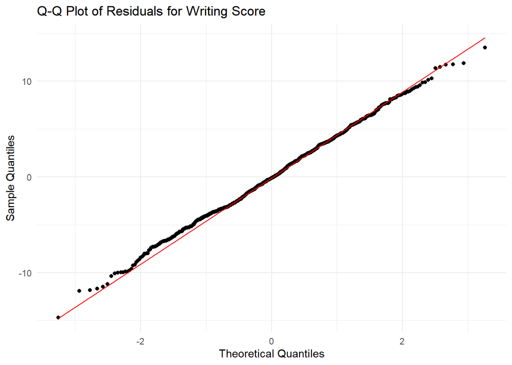

```r
writing_residuals <- residuals(backward_model_writing)

# Create a data frame for residuals
residuals_df <- data.frame(residuals = writing_residuals)

# Q-Q Plot
library(ggplot2)

ggplot(residuals_df, aes(sample = residuals)) +
  stat_qq() +
  stat_qq_line(color = "red") +
  labs(title = "Q-Q Plot of Residuals for Writing Score",
       x = "Theoretical Quantiles",
       y = "Sample Quantiles") +
  theme_minimal()
```

### Independence of Residuals

```r
dwtest(backward_model_writing)
```

```
##
##  Durbin-Watson test
##
## data:  backward_model_writing
## DW = 1.9532, p-value = 0.2416
## alternative hypothesis: true autocorrelation is greater than 0
```

### Multicollinearity Check

```r
vif(backward_model_writing)
```

```
##                       gender          ethnic_groupgroup_d
##                     1.077526                     1.010802
## parent_educassociates_degree       parent_educhigh_school
##                     1.555011                     1.556266
##      parent_educsome_college  parent_educsome_high_school
##                     1.564140                     1.497563
##                   lunch_type      practice_sportregularly
##                     1.077886                     2.384547
##      practice_sportsometimes                  nr_siblings
##                     2.375149                     1.006577
##          reading_score_trans
##                     1.179956
```

### constant variance

```r
bptest(backward_model_writing)
```

```
##
##  studentized Breusch-Pagan test
##
## data:  backward_model_writing
## BP = 18.937, df = 11, p-value = 0.06223
```

## Are the optimal prediction models similar or different across the three test scores?

We show the summary statistics for the model we build

```r
summary(backward_model_reading)
```

```
##
## Call:
## lm(formula = reading_score ~ gender + ethnic_groupgroup_d + ethnic_groupgroup_e +
##     parent_educassociates_degree + parent_educbachelors_degree +
##     parent_educmasters_degree + parent_educsome_college + lunch_type +
##     parent_marital_statusmarried + wkly_study_hours_10 + wkly_study_hours10_may,
##     data = model_data[, c(colnames(X_reading), "reading_score")])
##
## Residuals:
##     Min      1Q  Median      3Q     Max
## -45.306  -9.007   0.429   9.641  32.671
##
## Coefficients:
##                              Estimate Std. Error t value Pr(>|t|)
## (Intercept)                   59.6426     1.3379  44.578  < 2e-16 ***
## gender                        -7.0965     0.8995  -7.889 8.91e-15 ***
## ethnic_groupgroup_d            2.7144     1.0617   2.557 0.010736 *
## ethnic_groupgroup_e            4.7991     1.3785   3.481 0.000523 ***
## parent_educassociates_degree   5.2861     1.2093   4.371 1.38e-05 ***
## parent_educbachelors_degree    6.8839     1.5401   4.470 8.84e-06 ***
## parent_educmasters_degree      9.6802     1.9974   4.846 1.48e-06 ***
## parent_educsome_college        3.4823     1.1965   2.910 0.003700 **
## lunch_type                     7.4967     0.9402   7.974 4.70e-15 ***
## parent_marital_statusmarried   2.6168     0.9039   2.895 0.003884 **
## wkly_study_hours_10            2.6638     1.3963   1.908 0.056754 .
## wkly_study_hours10_may         2.7929     1.0155   2.750 0.006078 **
## ---
## Signif. codes:  0 '***' 0.001 '**' 0.01 '*' 0.05 '.' 0.1 ' ' 1
##
## Residual standard error: 13.43 on 890 degrees of freedom
## Multiple R-squared:  0.1886, Adjusted R-squared:  0.1786
## F-statistic: 18.81 on 11 and 890 DF,  p-value: < 2.2e-16
```

```r
summary(backward_model_writing)
```

```
##
## Call:
## lm(formula = writing_score ~ gender + ethnic_groupgroup_d + parent_educassociates_degree +
##     parent_educhigh_school + parent_educsome_college + parent_educsome_high_school +
##     lunch_type + practice_sportregularly + practice_sportsometimes +
##     nr_siblings + reading_score_trans, data = model_data[, c(colnames(X_writing),
##     "writing_score")])
##
## Residuals:
##      Min       1Q   Median       3Q      Max
## -14.7003  -3.1372  -0.1281   2.9278  13.4982
##
## Coefficients:
##                               Estimate Std. Error t value Pr(>|t|)
## (Intercept)                  16.845106   0.813312  20.712  < 2e-16 ***
## gender                       -2.269380   0.297789  -7.621 6.45e-14 ***
## ethnic_groupgroup_d           2.061229   0.331757   6.213 7.97e-10 ***
## parent_educassociates_degree -1.059593   0.441142  -2.402   0.0165 *
## parent_educhigh_school       -2.649147   0.459541  -5.765 1.13e-08 ***
## parent_educsome_college      -0.895980   0.437342  -2.049   0.0408 *
## parent_educsome_high_school  -2.481223   0.465213  -5.334 1.22e-07 ***
## lunch_type                    1.302389   0.311639   4.179 3.21e-05 ***
## practice_sportregularly       2.045989   0.460357   4.444 9.93e-06 ***
## practice_sportsometimes       1.048007   0.442037   2.371   0.0180 *
## nr_siblings                   0.160843   0.097056   1.657   0.0978 .
## reading_score_trans           0.254537   0.002831  89.926  < 2e-16 ***
## ---
## Signif. codes:  0 '***' 0.001 '**' 0.01 '*' 0.05 '.' 0.1 ' ' 1
##
## Residual standard error: 4.307 on 890 degrees of freedom
## Multiple R-squared:  0.9222, Adjusted R-squared:  0.9213
## F-statistic: 959.7 on 11 and 890 DF,  p-value: < 2.2e-16
```

```r
lasso_coef
```

```
## 28 x 1 sparse Matrix of class "dgCMatrix"
##                                        s1
## (Intercept)                   52.67990601
## gender                         4.83451570
## ethnic_groupgroup_a           -1.20425161
## ethnic_groupgroup_b            .
## ethnic_groupgroup_c           -0.17124538
## ethnic_groupgroup_d            2.85329898
## ethnic_groupgroup_e            8.30775230
## parent_educassociates_degree   2.75793157
## parent_educbachelors_degree    4.08186723
## parent_educhigh_school        -2.51577948
## parent_educmasters_degree      4.47899679
## parent_educsome_college        1.73533183
## parent_educsome_high_school   -1.38995421
## lunch_type                    10.81828274
## test_prep                      0.40327923
## parent_marital_statusdivorced -0.21940618
## parent_marital_statusmarried   2.62717738
## parent_marital_statussingle    .
## parent_marital_statuswidowed   3.42524285
## practice_sportnever           -1.51489960
## practice_sportregularly        0.44990389
## practice_sportsometimes        .
## is_first_child                 .
## nr_siblings                    0.09008143
## transport_means                0.18498076
## wkly_study_hours_5            -3.32360077
## wkly_study_hours_10            0.44160585
## wkly_study_hours10_may         .
```

Predictors for predicting math scores:gender, ethnic_groupgroup_a, ethnic_groupgroup_d, ethnic_groupgroup_e, parent_educassociates_degree, parent_educbachelors_degree, parent_educhigh_school, parent_educmasters_degree, parent_educsome_high_school, lunch_type, parent_marital_statusdivorced, parent_marital_statusmarried, parent_marital_statuswidowed, practice_sportnever, practice_sportregularly, wkly_study_hours_5, wkly_study_hours_10

So by comparing the predictors among the three optimal models, we can find out that the optimal prediction models are different across the three test scores.

## Is it possible to leverage one score as the auxiliary information to learn the model for another score (still its model against variables 1-11) better?

#### We can take math as an example

We can try to use criteria-based procedures, automatic search procedures, and shrink methods to test whether the best model contains the other two test scores we select in every method we use,

```r
X_math2 <- model_data %>%
  select(-math_score)
y_math2 <- model_data$math_score

# The initial full-variable model
full_model_math2 <- lm(math_score ~ ., data = model_data[, c(colnames(X_math2), "math_score")])

# backward elimination
backward_model_math2 <- stepAIC(full_model_math2, direction = "backward")
```

```
## Start:  AIC=3178.17
## math_score ~ gender + ethnic_groupgroup_a + ethnic_groupgroup_b +
##     ethnic_groupgroup_c + ethnic_groupgroup_d + ethnic_groupgroup_e +
##     parent_educassociates_degree + parent_educbachelors_degree +
##     parent_educhigh_school + parent_educmasters_degree + parent_educsome_college +
##     parent_educsome_high_school + lunch_type + test_prep + parent_marital_statusdivorced +
##     parent_marital_statusmarried + parent_marital_statussingle +
##     parent_marital_statuswidowed + practice_sportnever + practice_sportregularly +
##     practice_sportsometimes + is_first_child + nr_siblings +
##     transport_means + wkly_study_hours_5 + wkly_study_hours_10 +
##     wkly_study_hours10_may + reading_score + writing_score +
##     reading_score_trans
##
##                                 Df Sum of Sq   RSS    AIC
## - reading_score                  1         0 28548 3176.2
## - parent_marital_statussingle    1         0 28548 3176.2
## - practice_sportnever            1         0 28548 3176.2
## - parent_marital_statusdivorced  1         0 28548 3176.2
## - parent_educbachelors_degree    1         0 28549 3176.2
## - transport_means                1         2 28550 3176.2
## - parent_marital_statusmarried   1         2 28550 3176.2
## - parent_educsome_high_school    1         3 28551 3176.3
## - parent_educassociates_degree   1         3 28552 3176.3
## - practice_sportsometimes        1         5 28553 3176.3
## - test_prep                      1         8 28556 3176.4
## - parent_marital_statuswidowed   1         8 28557 3176.4
## - is_first_child                 1        13 28562 3176.6
## - ethnic_groupgroup_b            1        18 28567 3176.7
## - parent_educsome_college        1        25 28573 3177.0
## - practice_sportregularly        1        27 28575 3177.0
## - parent_educhigh_school         1        33 28581 3177.2
## - ethnic_groupgroup_d            1        56 28604 3177.9
## <none>                                       28548 3178.2
## - reading_score_trans            1        64 28612 3178.2
## - nr_siblings                    1        65 28613 3178.2
## - wkly_study_hours_10            1        68 28616 3178.3
## - ethnic_groupgroup_c            1       102 28650 3179.4
## - parent_educmasters_degree      1       114 28663 3179.8
## - ethnic_groupgroup_a            1       125 28673 3180.1
## - wkly_study_hours10_may         1       158 28706 3181.1
```

[output cut: 555 more lines]

```
##                             Df Sum of Sq   RSS    AIC
## <none>                                   28803 3152.2
## - ethnic_groupgroup_c        1        71 28874 3152.4
## - wkly_study_hours_10        1        76 28879 3152.6
## - nr_siblings                1        83 28885 3152.8
## - ethnic_groupgroup_a        1        91 28894 3153.0
## - wkly_study_hours10_may     1       172 28975 3155.5
## - practice_sportregularly    1       189 28991 3156.1
## - wkly_study_hours_5         1       318 29121 3160.1
## - parent_educmasters_degree  1       341 29144 3160.8
## - ethnic_groupgroup_e        1      1610 30413 3199.3
## - reading_score_trans        1      2393 31195 3222.2
## - lunch_type                 1      2629 31431 3229.0
## - writing_score              1      5477 34279 3307.2
## - gender                     1     32788 61591 3835.7
```

```r
summary(backward_model_math2)
```

```
##
## Call:
## lm(formula = math_score ~ gender + ethnic_groupgroup_a + ethnic_groupgroup_c +
##     ethnic_groupgroup_e + parent_educmasters_degree + lunch_type +
##     practice_sportregularly + nr_siblings + wkly_study_hours_5 +
##     wkly_study_hours_10 + wkly_study_hours10_may + writing_score +
##     reading_score_trans, data = model_data[, c(colnames(X_math2),
##     "math_score")])
##
## Residuals:
##      Min       1Q   Median       3Q      Max
## -18.2510  -3.7055   0.2542   3.7406  15.1458
##
## Coefficients:
##                           Estimate Std. Error t value Pr(>|t|)
## (Intercept)                1.14669    1.46319   0.784  0.43343
## gender                    12.87652    0.40499  31.794  < 2e-16 ***
## ethnic_groupgroup_a       -1.21245    0.72269  -1.678  0.09376 .
## ethnic_groupgroup_c       -0.66093    0.44658  -1.480  0.13924
## ethnic_groupgroup_e        4.22759    0.59998   7.046 3.69e-12 ***
## parent_educmasters_degree -2.68594    0.82863  -3.241  0.00123 **
## lunch_type                 3.73750    0.41517   9.002  < 2e-16 ***
## practice_sportregularly    0.96378    0.39963   2.412  0.01608 *
## nr_siblings                0.20581    0.12899   1.596  0.11095
## wkly_study_hours_5        -3.16407    1.01058  -3.131  0.00180 **
## wkly_study_hours_10       -1.61769    1.05807  -1.529  0.12664
## wkly_study_hours10_may    -2.25040    0.97759  -2.302  0.02157 *
## writing_score              0.55584    0.04278  12.994  < 2e-16 ***
## reading_score_trans        0.10009    0.01165   8.589  < 2e-16 ***
## ---
## Signif. codes:  0 '***' 0.001 '**' 0.01 '*' 0.05 '.' 0.1 ' ' 1
##
## Residual standard error: 5.695 on 888 degrees of freedom
## Multiple R-squared:  0.8678, Adjusted R-squared:  0.8659
## F-statistic: 448.5 on 13 and 888 DF,  p-value: < 2.2e-16
```

## criteria-based

```r
# Perform stepwise selection based on AIC using stepAIC
aic_model_math2 <- stepAIC(full_model_math2, direction = "both", k = 2)
```

```
## Start:  AIC=3178.17
## math_score ~ gender + ethnic_groupgroup_a + ethnic_groupgroup_b +
##     ethnic_groupgroup_c + ethnic_groupgroup_d + ethnic_groupgroup_e +
##     parent_educassociates_degree + parent_educbachelors_degree +
##     parent_educhigh_school + parent_educmasters_degree + parent_educsome_college +
##     parent_educsome_high_school + lunch_type + test_prep + parent_marital_statusdivorced +
##     parent_marital_statusmarried + parent_marital_statussingle +
##     parent_marital_statuswidowed + practice_sportnever + practice_sportregularly +
##     practice_sportsometimes + is_first_child + nr_siblings +
##     transport_means + wkly_study_hours_5 + wkly_study_hours_10 +
##     wkly_study_hours10_may + reading_score + writing_score +
##     reading_score_trans
##
##                                 Df Sum of Sq   RSS    AIC
## - reading_score                  1         0 28548 3176.2
## - parent_marital_statussingle    1         0 28548 3176.2
## - practice_sportnever            1         0 28548 3176.2
## - parent_marital_statusdivorced  1         0 28548 3176.2
## - parent_educbachelors_degree    1         0 28549 3176.2
## - transport_means                1         2 28550 3176.2
## - parent_marital_statusmarried   1         2 28550 3176.2
## - parent_educsome_high_school    1         3 28551 3176.3
## - parent_educassociates_degree   1         3 28552 3176.3
## - practice_sportsometimes        1         5 28553 3176.3
## - test_prep                      1         8 28556 3176.4
## - parent_marital_statuswidowed   1         8 28557 3176.4
## - is_first_child                 1        13 28562 3176.6
## - ethnic_groupgroup_b            1        18 28567 3176.7
## - parent_educsome_college        1        25 28573 3177.0
## - practice_sportregularly        1        27 28575 3177.0
## - parent_educhigh_school         1        33 28581 3177.2
## - ethnic_groupgroup_d            1        56 28604 3177.9
## <none>                                       28548 3178.2
## - reading_score_trans            1        64 28612 3178.2
## - nr_siblings                    1        65 28613 3178.2
## - wkly_study_hours_10            1        68 28616 3178.3
## - ethnic_groupgroup_c            1       102 28650 3179.4
## - parent_educmasters_degree      1       114 28663 3179.8
## - ethnic_groupgroup_a            1       125 28673 3180.1
## - wkly_study_hours10_may         1       158 28706 3181.1
```

[output cut: 708 more lines]

```
## + parent_marital_statussingle    1         9 28794 3153.9
## + parent_marital_statusdivorced  1         8 28795 3153.9
## + ethnic_groupgroup_b            1         6 28796 3154.0
## + parent_educassociates_degree   1         5 28798 3154.0
## + transport_means                1         1 28802 3154.1
## + reading_score                  1         0 28803 3154.2
## - wkly_study_hours10_may         1       172 28975 3155.5
## - practice_sportregularly        1       189 28991 3156.1
## - wkly_study_hours_5             1       318 29121 3160.1
## - parent_educmasters_degree      1       341 29144 3160.8
## - ethnic_groupgroup_e            1      1610 30413 3199.3
## - reading_score_trans            1      2393 31195 3222.2
## - lunch_type                     1      2629 31431 3229.0
## - writing_score                  1      5477 34279 3307.2
## - gender                         1     32788 61591 3835.7
```

```r
summary(aic_model_math2)
```

```
##
## Call:
## lm(formula = math_score ~ gender + ethnic_groupgroup_a + ethnic_groupgroup_c +
##     ethnic_groupgroup_e + parent_educmasters_degree + lunch_type +
##     practice_sportregularly + nr_siblings + wkly_study_hours_5 +
##     wkly_study_hours_10 + wkly_study_hours10_may + writing_score +
##     reading_score_trans, data = model_data[, c(colnames(X_math2),
##     "math_score")])
##
## Residuals:
##      Min       1Q   Median       3Q      Max
## -18.2510  -3.7055   0.2542   3.7406  15.1458
##
## Coefficients:
##                           Estimate Std. Error t value Pr(>|t|)
## (Intercept)                1.14669    1.46319   0.784  0.43343
## gender                    12.87652    0.40499  31.794  < 2e-16 ***
## ethnic_groupgroup_a       -1.21245    0.72269  -1.678  0.09376 .
## ethnic_groupgroup_c       -0.66093    0.44658  -1.480  0.13924
## ethnic_groupgroup_e        4.22759    0.59998   7.046 3.69e-12 ***
## parent_educmasters_degree -2.68594    0.82863  -3.241  0.00123 **
## lunch_type                 3.73750    0.41517   9.002  < 2e-16 ***
## practice_sportregularly    0.96378    0.39963   2.412  0.01608 *
## nr_siblings                0.20581    0.12899   1.596  0.11095
## wkly_study_hours_5        -3.16407    1.01058  -3.131  0.00180 **
## wkly_study_hours_10       -1.61769    1.05807  -1.529  0.12664
## wkly_study_hours10_may    -2.25040    0.97759  -2.302  0.02157 *
## writing_score              0.55584    0.04278  12.994  < 2e-16 ***
## reading_score_trans        0.10009    0.01165   8.589  < 2e-16 ***
## ---
## Signif. codes:  0 '***' 0.001 '**' 0.01 '*' 0.05 '.' 0.1 ' ' 1
##
## Residual standard error: 5.695 on 888 degrees of freedom
## Multiple R-squared:  0.8678, Adjusted R-squared:  0.8659
## F-statistic: 448.5 on 13 and 888 DF,  p-value: < 2.2e-16
```

```r
# Perform stepwise selection based on BIC using stepAIC
bic_model_math2 <- stepAIC(full_model_math2, direction = "both", k = log(nrow(model_data)))
```

```
## Start:  AIC=3327.11
## math_score ~ gender + ethnic_groupgroup_a + ethnic_groupgroup_b +
##     ethnic_groupgroup_c + ethnic_groupgroup_d + ethnic_groupgroup_e +
##     parent_educassociates_degree + parent_educbachelors_degree +
##     parent_educhigh_school + parent_educmasters_degree + parent_educsome_college +
##     parent_educsome_high_school + lunch_type + test_prep + parent_marital_statusdivorced +
##     parent_marital_statusmarried + parent_marital_statussingle +
##     parent_marital_statuswidowed + practice_sportnever + practice_sportregularly +
##     practice_sportsometimes + is_first_child + nr_siblings +
##     transport_means + wkly_study_hours_5 + wkly_study_hours_10 +
##     wkly_study_hours10_may + reading_score + writing_score +
##     reading_score_trans
##
##                                 Df Sum of Sq   RSS    AIC
## - reading_score                  1         0 28548 3320.3
## - parent_marital_statussingle    1         0 28548 3320.3
## - practice_sportnever            1         0 28548 3320.3
## - parent_marital_statusdivorced  1         0 28548 3320.3
## - parent_educbachelors_degree    1         0 28549 3320.3
## - transport_means                1         2 28550 3320.4
## - parent_marital_statusmarried   1         2 28550 3320.4
## - parent_educsome_high_school    1         3 28551 3320.4
## - parent_educassociates_degree   1         3 28552 3320.4
## - practice_sportsometimes        1         5 28553 3320.5
## - test_prep                      1         8 28556 3320.6
## - parent_marital_statuswidowed   1         8 28557 3320.6
## - is_first_child                 1        13 28562 3320.7
## - ethnic_groupgroup_b            1        18 28567 3320.9
## - parent_educsome_college        1        25 28573 3321.1
## - practice_sportregularly        1        27 28575 3321.2
## - parent_educhigh_school         1        33 28581 3321.4
## - ethnic_groupgroup_d            1        56 28604 3322.1
## - reading_score_trans            1        64 28612 3322.3
## - nr_siblings                    1        65 28613 3322.4
## - wkly_study_hours_10            1        68 28616 3322.4
## - ethnic_groupgroup_c            1       102 28650 3323.5
## - parent_educmasters_degree      1       114 28663 3323.9
## - ethnic_groupgroup_a            1       125 28673 3324.2
## - wkly_study_hours10_may         1       158 28706 3325.3
## <none>                                       28548 3327.1
```

[output cut: 938 more lines]

```
## + parent_educsome_high_school    1        13 29378 3203.3
## + test_prep                      1        13 29379 3203.3
## + parent_marital_statusdivorced  1        10 29382 3203.4
## + parent_marital_statusmarried   1         9 29383 3203.4
## + is_first_child                 1         9 29383 3203.4
## + parent_educassociates_degree   1         4 29387 3203.5
## + parent_marital_statussingle    1         3 29389 3203.6
## + reading_score                  1         0 29391 3203.7
## + ethnic_groupgroup_d            1         0 29391 3203.7
## + transport_means                1         0 29391 3203.7
## - reading_score_trans            1      2101 31492 3252.3
## - ethnic_groupgroup_e            1      2187 31579 3254.8
## - lunch_type                     1      2547 31939 3265.0
## - writing_score                  1      6273 35665 3364.6
## - gender                         1     33245 62637 3872.6
```

```r
summary(bic_model_math2)
```

```
##
## Call:
## lm(formula = math_score ~ gender + ethnic_groupgroup_e + parent_educmasters_degree +
##     lunch_type + wkly_study_hours_5 + writing_score + reading_score_trans,
##     data = model_data[, c(colnames(X_math2), "math_score")])
##
## Residuals:
##      Min       1Q   Median       3Q      Max
## -17.6181  -3.7122   0.3146   3.7765  15.0428
##
## Coefficients:
##                           Estimate Std. Error t value Pr(>|t|)
## (Intercept)               -0.84933    1.09698  -0.774 0.438993
## gender                    12.92933    0.40659  31.799  < 2e-16 ***
## ethnic_groupgroup_e        4.69314    0.57543   8.156 1.17e-15 ***
## parent_educmasters_degree -2.88363    0.82859  -3.480 0.000525 ***
## lunch_type                 3.66745    0.41668   8.802  < 2e-16 ***
## wkly_study_hours_5        -1.13044    0.43428  -2.603 0.009394 **
## writing_score              0.58514    0.04236  13.813  < 2e-16 ***
## reading_score_trans        0.09243    0.01156   7.994 4.03e-15 ***
## ---
## Signif. codes:  0 '***' 0.001 '**' 0.01 '*' 0.05 '.' 0.1 ' ' 1
##
## Residual standard error: 5.734 on 894 degrees of freedom
## Multiple R-squared:  0.8651, Adjusted R-squared:  0.8641
## F-statistic: 819.2 on 7 and 894 DF,  p-value: < 2.2e-16
```

## lasso

```r
# transform data into matrix
X_matrix_2 <- model.matrix(~ . - 1, data = X_math2)
y_vector_2 <- as.numeric(y_math2)

#  LASSO
lasso_model_math2 <- cv.glmnet(X_matrix_2, y_vector_2, alpha = 1, nfolds = 5)

# lambda
lambda_min_math2 <- lasso_model_math2$lambda.min


lasso_coef_math2 <- coef(lasso_model_math2, s = lambda_min_math2)
print(lasso_coef_math2)
```

```
## 31 x 1 sparse Matrix of class "dgCMatrix"
##                                        s1
## (Intercept)                   -2.06221831
## gender                        12.37736591
## ethnic_groupgroup_a           -0.37895135
## ethnic_groupgroup_b            .
## ethnic_groupgroup_c           -0.31677972
## ethnic_groupgroup_d            .
## ethnic_groupgroup_e            4.05517255
## parent_educassociates_degree   .
## parent_educbachelors_degree    .
## parent_educhigh_school         0.06196550
## parent_educmasters_degree     -1.75919124
## parent_educsome_college        0.16213286
## parent_educsome_high_school    .
## lunch_type                     3.48462757
## test_prep                      .
## parent_marital_statusdivorced  .
## parent_marital_statusmarried   .
## parent_marital_statussingle    .
## parent_marital_statuswidowed   .
## practice_sportnever           -0.19597162
## practice_sportregularly        0.52346447
## practice_sportsometimes        .
## is_first_child                 .
## nr_siblings                    0.06410552
## transport_means                .
## wkly_study_hours_5            -0.75665468
## wkly_study_hours_10            0.15770677
## wkly_study_hours10_may         .
## reading_score                  0.17285416
## writing_score                  0.54650246
## reading_score_trans            0.05205277
```

## comparison

```r
summary(backward_model_math2)
```

```
##
## Call:
## lm(formula = math_score ~ gender + ethnic_groupgroup_a + ethnic_groupgroup_c +
##     ethnic_groupgroup_e + parent_educmasters_degree + lunch_type +
##     practice_sportregularly + nr_siblings + wkly_study_hours_5 +
##     wkly_study_hours_10 + wkly_study_hours10_may + writing_score +
##     reading_score_trans, data = model_data[, c(colnames(X_math2),
##     "math_score")])
##
## Residuals:
##      Min       1Q   Median       3Q      Max
## -18.2510  -3.7055   0.2542   3.7406  15.1458
##
## Coefficients:
##                           Estimate Std. Error t value Pr(>|t|)
## (Intercept)                1.14669    1.46319   0.784  0.43343
## gender                    12.87652    0.40499  31.794  < 2e-16 ***
## ethnic_groupgroup_a       -1.21245    0.72269  -1.678  0.09376 .
## ethnic_groupgroup_c       -0.66093    0.44658  -1.480  0.13924
## ethnic_groupgroup_e        4.22759    0.59998   7.046 3.69e-12 ***
## parent_educmasters_degree -2.68594    0.82863  -3.241  0.00123 **
## lunch_type                 3.73750    0.41517   9.002  < 2e-16 ***
## practice_sportregularly    0.96378    0.39963   2.412  0.01608 *
## nr_siblings                0.20581    0.12899   1.596  0.11095
## wkly_study_hours_5        -3.16407    1.01058  -3.131  0.00180 **
## wkly_study_hours_10       -1.61769    1.05807  -1.529  0.12664
## wkly_study_hours10_may    -2.25040    0.97759  -2.302  0.02157 *
## writing_score              0.55584    0.04278  12.994  < 2e-16 ***
## reading_score_trans        0.10009    0.01165   8.589  < 2e-16 ***
## ---
## Signif. codes:  0 '***' 0.001 '**' 0.01 '*' 0.05 '.' 0.1 ' ' 1
##
## Residual standard error: 5.695 on 888 degrees of freedom
## Multiple R-squared:  0.8678, Adjusted R-squared:  0.8659
## F-statistic: 448.5 on 13 and 888 DF,  p-value: < 2.2e-16
```

```r
summary(aic_model_math2)
```

```
##
## Call:
## lm(formula = math_score ~ gender + ethnic_groupgroup_a + ethnic_groupgroup_c +
##     ethnic_groupgroup_e + parent_educmasters_degree + lunch_type +
##     practice_sportregularly + nr_siblings + wkly_study_hours_5 +
##     wkly_study_hours_10 + wkly_study_hours10_may + writing_score +
##     reading_score_trans, data = model_data[, c(colnames(X_math2),
##     "math_score")])
##
## Residuals:
##      Min       1Q   Median       3Q      Max
## -18.2510  -3.7055   0.2542   3.7406  15.1458
##
## Coefficients:
##                           Estimate Std. Error t value Pr(>|t|)
## (Intercept)                1.14669    1.46319   0.784  0.43343
## gender                    12.87652    0.40499  31.794  < 2e-16 ***
## ethnic_groupgroup_a       -1.21245    0.72269  -1.678  0.09376 .
## ethnic_groupgroup_c       -0.66093    0.44658  -1.480  0.13924
## ethnic_groupgroup_e        4.22759    0.59998   7.046 3.69e-12 ***
## parent_educmasters_degree -2.68594    0.82863  -3.241  0.00123 **
## lunch_type                 3.73750    0.41517   9.002  < 2e-16 ***
## practice_sportregularly    0.96378    0.39963   2.412  0.01608 *
## nr_siblings                0.20581    0.12899   1.596  0.11095
## wkly_study_hours_5        -3.16407    1.01058  -3.131  0.00180 **
## wkly_study_hours_10       -1.61769    1.05807  -1.529  0.12664
## wkly_study_hours10_may    -2.25040    0.97759  -2.302  0.02157 *
## writing_score              0.55584    0.04278  12.994  < 2e-16 ***
## reading_score_trans        0.10009    0.01165   8.589  < 2e-16 ***
## ---
## Signif. codes:  0 '***' 0.001 '**' 0.01 '*' 0.05 '.' 0.1 ' ' 1
##
## Residual standard error: 5.695 on 888 degrees of freedom
## Multiple R-squared:  0.8678, Adjusted R-squared:  0.8659
## F-statistic: 448.5 on 13 and 888 DF,  p-value: < 2.2e-16
```

```r
summary(bic_model_math2)
```

```
##
## Call:
## lm(formula = math_score ~ gender + ethnic_groupgroup_e + parent_educmasters_degree +
##     lunch_type + wkly_study_hours_5 + writing_score + reading_score_trans,
##     data = model_data[, c(colnames(X_math2), "math_score")])
##
## Residuals:
##      Min       1Q   Median       3Q      Max
## -17.6181  -3.7122   0.3146   3.7765  15.0428
##
## Coefficients:
##                           Estimate Std. Error t value Pr(>|t|)
## (Intercept)               -0.84933    1.09698  -0.774 0.438993
## gender                    12.92933    0.40659  31.799  < 2e-16 ***
## ethnic_groupgroup_e        4.69314    0.57543   8.156 1.17e-15 ***
## parent_educmasters_degree -2.88363    0.82859  -3.480 0.000525 ***
## lunch_type                 3.66745    0.41668   8.802  < 2e-16 ***
## wkly_study_hours_5        -1.13044    0.43428  -2.603 0.009394 **
## writing_score              0.58514    0.04236  13.813  < 2e-16 ***
## reading_score_trans        0.09243    0.01156   7.994 4.03e-15 ***
## ---
## Signif. codes:  0 '***' 0.001 '**' 0.01 '*' 0.05 '.' 0.1 ' ' 1
##
## Residual standard error: 5.734 on 894 degrees of freedom
## Multiple R-squared:  0.8651, Adjusted R-squared:  0.8641
## F-statistic: 819.2 on 7 and 894 DF,  p-value: < 2.2e-16
```

```r
print(lasso_coef_math2)
```

```
## 31 x 1 sparse Matrix of class "dgCMatrix"
##                                        s1
## (Intercept)                   -2.06221831
## gender                        12.37736591
## ethnic_groupgroup_a           -0.37895135
## ethnic_groupgroup_b            .
## ethnic_groupgroup_c           -0.31677972
## ethnic_groupgroup_d            .
## ethnic_groupgroup_e            4.05517255
## parent_educassociates_degree   .
## parent_educbachelors_degree    .
## parent_educhigh_school         0.06196550
## parent_educmasters_degree     -1.75919124
## parent_educsome_college        0.16213286
## parent_educsome_high_school    .
## lunch_type                     3.48462757
## test_prep                      .
## parent_marital_statusdivorced  .
## parent_marital_statusmarried   .
## parent_marital_statussingle    .
## parent_marital_statuswidowed   .
## practice_sportnever           -0.19597162
## practice_sportregularly        0.52346447
## practice_sportsometimes        .
## is_first_child                 .
## nr_siblings                    0.06410552
## transport_means                .
## wkly_study_hours_5            -0.75665468
## wkly_study_hours_10            0.15770677
## wkly_study_hours10_may         .
## reading_score                  0.17285416
## writing_score                  0.54650246
## reading_score_trans            0.05205277
```

Here we can see that all the models built on different selection criteria contain writing score and possibly reading score

```r
# compare AIC/BIC
aic_backward_math2 <- AIC(backward_model_math2)
bic_backward_math2 <- BIC(backward_model_math2)
# Backward elimination R2
r2_backward_math2 <- summary(backward_model_math2)$r.squared
adj_r2_backward_math2 <- summary(backward_model_math2)$adj.r.squared


aic_aic_model_math2 <- AIC(aic_model_math2)
bic_aic_model_math2 <- BIC(aic_model_math2)

aic_bic_model_math2 <- AIC(bic_model_math2)
bic_bic_model_math2 <- BIC(bic_model_math2)
# R2 of AIC model
r2_aic_math2 <- summary(aic_model_math2)$r.squared
adj_r2_aic_math2 <- summary(aic_model_math2)$adj.r.squared

# R2 if BIC model
r2_bic_math2 <- summary(bic_model_math2)$r.squared
adj_r2_bic_math2 <- summary(bic_model_math2)$adj.r.squared


# compare AIC/BIC of LASSO
predictions_math2 <- predict(lasso_model_math2, newx = X_matrix_2, s = lambda_min_math2)
rss_math2 <- sum((y_vector_2 - predictions_math2)^2)
n <- length(y_vector_2)
k <- sum(lasso_coef != 0)
aic_lasso_math2 <- n * log(rss / n) + 2 * k
bic_lasso_math2 <- n * log(rss / n) + log(n) * k

# prediction of lasso
predictions_math2 <- predict(lasso_model_math2, newx = X_matrix_2, s = lambda_min_math2)

# RSS and TSS
rss_math2 <- sum((y_vector_2 - predictions_math2)^2)
tss_math2 <- sum((y_vector_2 - mean(y_vector_2))^2)

# adjusted R2 of LASSO
r2_lasso_math2 <- 1 - (rss_math2 / tss_math2)
adj_r2_lasso_math2 <- 1 - ((1 - r2_lasso_math2) * (n - 1) / (n - k - 1))

results_math2 <- data.frame(
  Method = c("Backward", "Criteria-Based AIC", "Criteria-Based BIC", "LASSO"),
  AIC_ = c(aic_backward_math2, aic_aic_model_math2, aic_bic_model_math2, aic_lasso_math2),
  BIC = c(bic_backward_math2, bic_aic_model_math2, bic_bic_model_math2, bic_lasso_math2),
  Adj_R2 = c(adj_r2_backward_math2, adj_r2_aic_math2, adj_r2_bic_math2, adj_r2_lasso_math2)
)

print(results_math2)
```

```
##               Method     AIC_      BIC    Adj_R2
## 1           Backward 5713.944 5786.014 0.8658950
## 2 Criteria-Based AIC 5713.944 5786.014 0.8658950
## 3 Criteria-Based BIC 5720.200 5763.442 0.8640716
## 4              LASSO 4732.643 4843.149 0.8622029
```

And the best model that contain possibly the other two scores have a lower AIC and BIC metrics and higher Adjusted R^2 value. Hence, the result shows that it is possible to leverage one score as the auxiliary information to learn the model for another score (still its model against variables 1-11) better.